# Práctico 1. Estimación de la selección fenotípica.

Modificado de Palacio, F.X., Ordano, M. & Benitez-Vieyra, S. 2019. Measuring natural selection on multivariate phenotypic traits: a protocol for verifiable and reproducible analyses of natural selection. *Israel Journal of Ecology and Evolution* 65, 130–136.

*Los datos de este ejemplo fueron obtenidos de:*  
Benitez‐Vieyra, S., Medina, A.M., Glinos, E. & Cocucci, A.A. 2006. Pollinator-mediated selection on floral traits and size of floral display in *Cyclopogon elatus*, a sweat bee-pollinated orchid. *Functional Ecology* 20, 948–957.

#### Cargando paquetes y el set de datos

```r
library(car)
library(boot)
library(visreg)
library(ggplot2)
library(knitr)

data <- read.table("cyclop.txt", header = TRUE)
data <- na.omit(data)
```

#### Paso 1. Obtener el éxito reproductivo relativo y estandarizar los rasgos fenotípicos (media = 0, varianza = 1)

```r
W <- data$exported.pollinaria
wrel <- W/mean(W)
x1 <- data$flower.number
x2 <- data$nectary.depth
z1 <- (x1 - mean(x1))/sd(x1)
z2 <- (x2 - mean(x2))/sd(x2)
```

#### Paso 2. Colinearidad de los rasgos fenotípicos

Factores de inflación de la varianza en el modelo (lineal) de Lande & Arnold.

```r
lin.grad <- lm(wrel ~ z1 + z2)
kable(vif(lin.grad), digits = 4)
```

|  | x |
| --- | --- |
| z1 | 1.0462 |
| z2 | 1.0462 |

#### Paso 3. Construir y chequear el modelo (lineal y completo) de Lande & Arnold

```r
lin.grad <- lm(wrel ~ z1 + z2)
kable(summary(lin.grad)$coeff, digits = 4)
```

|  | Estimate | Std. Error | t value | Pr(>\|t\|) |
| --- | --- | --- | --- | --- |
| (Intercept) | 1.0000 | 0.0379 | 26.4090 | 0 |
| z1 | 0.6516 | 0.0389 | 16.7524 | 0 |
| z2 | 0.1977 | 0.0389 | 5.0825 | 0 |

```r
nonlin.grad <- lm(wrel ~ z1 + z2 + I(0.5*z1^2) + I(0.5*z2^2) + z1:z2)
kable(summary(nonlin.grad)$coeff, digits = 4)
```

|  | Estimate | Std. Error | t value | Pr(>\|t\|) |
| --- | --- | --- | --- | --- |
| (Intercept) | 1.1118 | 0.0508 | 21.8917 | 0.0000 |
| z1 | 0.7796 | 0.0546 | 14.2890 | 0.0000 |
| z2 | 0.1734 | 0.0368 | 4.7169 | 0.0000 |
| I(0.5 * z1^2) | -0.1998 | 0.0643 | -3.1088 | 0.0024 |
| I(0.5 * z2^2) | -0.0861 | 0.0565 | -1.5238 | 0.1304 |
| z1:z2 | 0.1434 | 0.0375 | 3.8221 | 0.0002 |

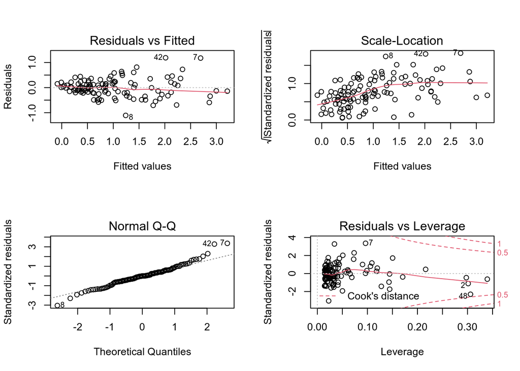

```r
layout(matrix(1:4, 2, 2))
plot(nonlin.grad)
```

```r
layout(1)
```

#### Paso 4. Intervalos de confianza

Para la función *grad*, los datos deben tener el éxito reproductivo relativo en la primer columna y las variabes estandarizadas en las subsecuentes columnas. La función retorna un vector con los gradientes lineales, cuadráticos y correlacionales, y representa la entrada de la función boot.

```r
grad <- function(data, original = c(1:nrow(data))){
  data <- data[original, ]
  vars  <- colnames(data)[-1]
  colnames(data)[1] <- "Wrel"
  model.lin <- as.formula(paste("Wrel", paste(vars, collapse=" + "), sep=" ~ "))
  m1 <- lm(formula = model.lin, data = data)
  part1 <- paste("(", paste(vars, collapse=" + "), ")^2", sep = "")
  part2 <- paste("I(0.5*(", vars, "^2))", sep = "", collapse = " + ")
  model.qua <- as.formula <- paste("Wrel", paste(part1, part2, sep = " + "), sep = " ~ ")
  m2 <- lm(formula = model.qua, data = data)
  sel.grad<-c(m1$coefficients[-1], m2$coefficients[-c(1:ncol(data))])
  return(sel.grad)
}

newdata <- data.frame(wrel, z1, z2)
selection.gradients <- grad(data = newdata)
boot.grad <- boot(data = newdata, statistic = grad, R = 999)
```

Intervalos de confianza BCA para cada gradiente.

```r
CI <- list()
for(i in 1:length(boot.grad$t0)){
  CI[[i]] <- boot.ci(boot.grad, conf = 0.95, type = "bca", index = i)$bca[4:5]
}

names(CI) <- names(boot.grad$t0)
CI <- cbind(selection.gradients, do.call(rbind, CI))
colnames(CI) <-c("sel. gradients", "lower.ci", "upper.ci")
kable(CI, digits = 4)
```

|  | sel. gradients | lower.ci | upper.ci |
| --- | --- | --- | --- |
| z1 | 0.6516 | 0.5196 | 0.7835 |
| z2 | 0.1977 | 0.1218 | 0.2948 |
| I(0.5 * (z1^2)) | -0.1998 | -0.3522 | -0.0498 |
| I(0.5 * (z2^2)) | -0.0861 | -0.2376 | 0.0363 |
| z1:z2 | 0.1434 | 0.0335 | 0.2750 |

#### Paso 5. Graficando los resultados del modelo de Lande & Arnold.

5.1. Selección lineal

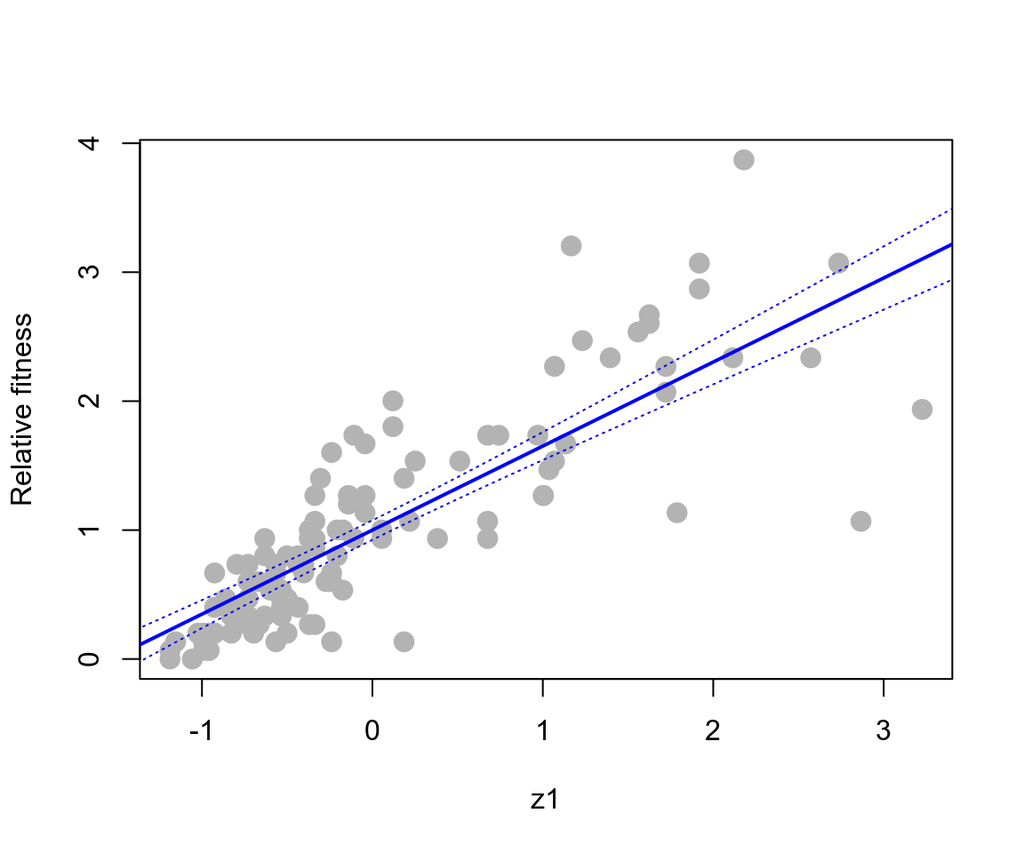

```r
new.z1 <- seq(-4, 4, length = 500)
plot(z1, wrel, pch = 19, cex = 1.5, col = "gray70", ylab = "Relative fitness")
pred.z1 <- predict(lin.grad, newdata = data.frame(z1 = new.z1, z2 = mean(z2)),
                   se.fit = TRUE)
lines(new.z1, pred.z1$fit, lwd = 2, col = "blue")
lines(new.z1, pred.z1$fit + 2*pred.z1$se.fit, lty = 3, col = "blue")
lines(new.z1, pred.z1$fit - 2*pred.z1$se.fit, lty = 3, col = "blue")
```

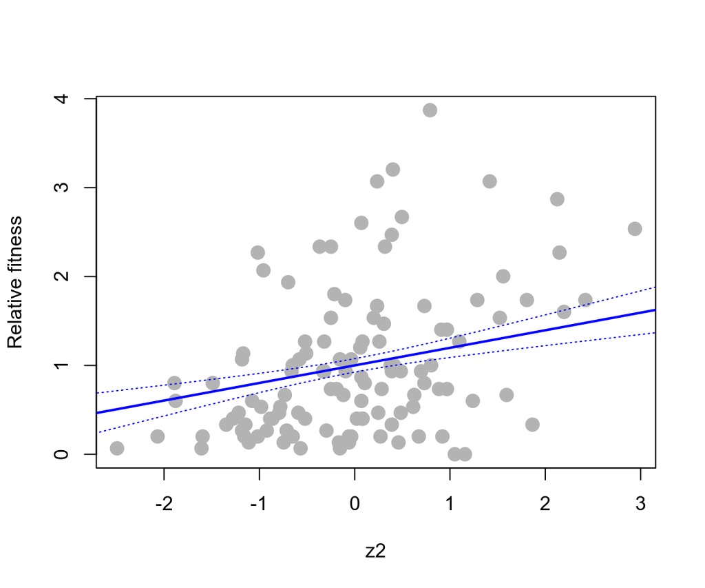

```r
new.z2 <- seq(-4, 4, length = 500)
plot(z2, wrel, pch = 19, cex = 1.5, col = "gray70", ylab = "Relative fitness")
pred.z2 <- predict(lin.grad, newdata = data.frame(z1 = mean(z1), z2 = new.z2),
                   se.fit = TRUE)
lines(new.z2, pred.z2$fit, lwd = 2, col = "blue")
lines(new.z2, pred.z2$fit + 2*pred.z2$se.fit, lty = 3, col = "blue")
lines(new.z2, pred.z2$fit - 2*pred.z2$se.fit, lty = 3, col = "blue")
```

5.2. Selección no-lineal

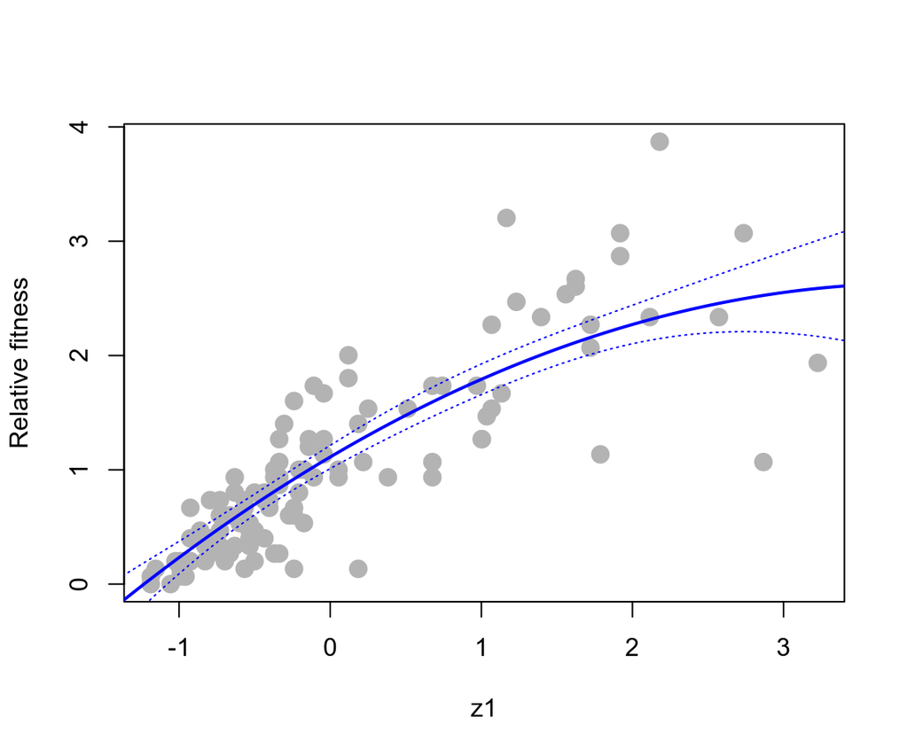

```r
new.z1 <- seq(-4, 4, length = 500)
plot(z1, wrel, pch = 19, cex = 1.5, col = "gray70", ylab = "Relative fitness")
pred.z1 <- predict(nonlin.grad, newdata = data.frame(z1 = new.z1, z2 = mean(z2)),
                   se.fit = TRUE)
lines(new.z1, pred.z1$fit, lwd = 2, col = "blue")
lines(new.z1, pred.z1$fit + 2*pred.z1$se.fit, lty = 3, col = "blue")
lines(new.z1, pred.z1$fit - 2*pred.z1$se.fit, lty = 3, col = "blue")
```

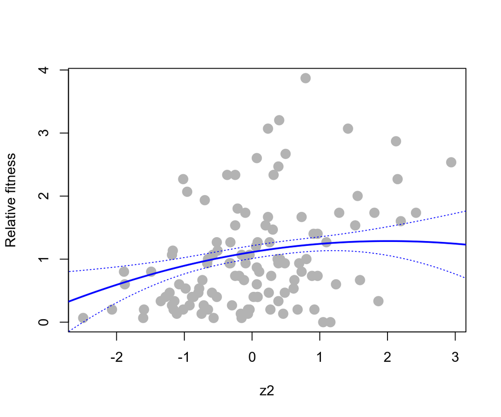

```r
new.z2 <- seq(-4, 4, length = 500)
plot(z2, wrel, pch = 19, cex = 1.5, col = "gray70", ylab = "Relative fitness")
pred.z2 <- predict(nonlin.grad, newdata = data.frame(z1 = mean(z1), z2 = new.z2),
                   se.fit = TRUE)
lines(new.z2, pred.z2$fit, lwd = 2, col = "blue")
lines(new.z2, pred.z2$fit + 2*pred.z2$se.fit, lty = 3, col = "blue")
lines(new.z2, pred.z2$fit - 2*pred.z2$se.fit, lty = 3, col = "blue")
```

5.3. Selección correlacional

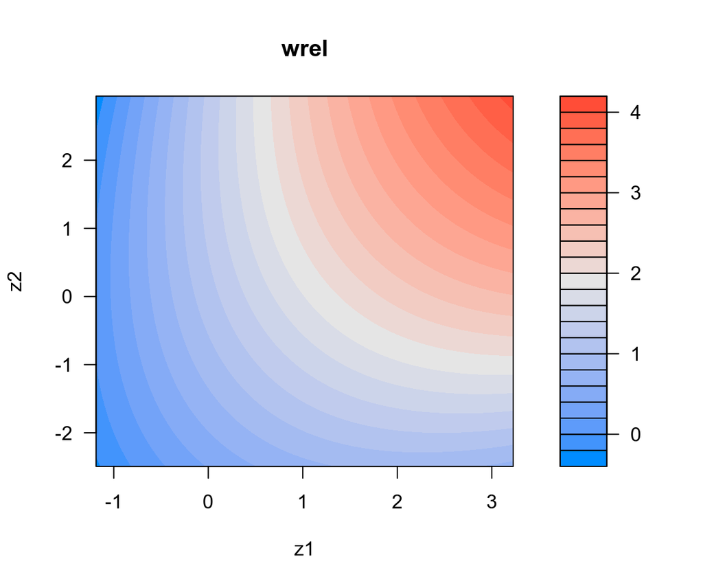

```r
nonlin.grad <- lm(wrel ~ z1 + z2 + I(0.5*z1^2) + I(0.5*z2^2) + z1:z2)
visreg2d(nonlin.grad, xvar = "z1", yvar = "z2", scale = "response", plot.type = "image")
```

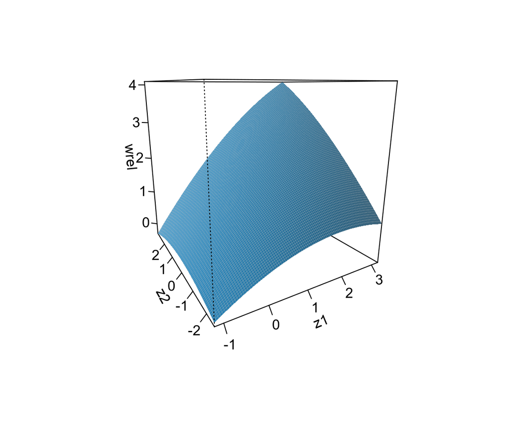

```r
visreg2d(nonlin.grad, xvar = "z1", yvar = "z2", scale = "response", plot.type = "persp")
```

#### 6. Otras medidas comunes en estudios de selección fenotípica

**Oportunidad para la selección** $I$

```r
op <- var(wrel)
op
```

```
## [1] 0.6812934
```

**Diferenciales de selección lineal** $s_i$

```r
s1 <- lm(wrel ~ z1)
summary(s1)
```

```
##
## Call:
## lm(formula = wrel ~ z1)
##
## Residuals:
##      Min       1Q   Median       3Q      Max
## -1.91916 -0.21458 -0.05215  0.23904  1.39507
##
## Coefficients:
##             Estimate Std. Error t value Pr(>|t|)
## (Intercept)  1.00000    0.04179   23.93   <2e-16 ***
## z1           0.69318    0.04197   16.52   <2e-16 ***
## ---
## Signif. codes:  0 '***' 0.001 '**' 0.01 '*' 0.05 '.' 0.1 ' ' 1
##
## Residual standard error: 0.4501 on 114 degrees of freedom
## Multiple R-squared:  0.7053, Adjusted R-squared:  0.7027
## F-statistic: 272.8 on 1 and 114 DF,  p-value: < 2.2e-16
```

```r
s2 <- lm(wrel ~ z2)
summary(s2)
```

```
##
## Call:
## lm(formula = wrel ~ z2)
##
## Residuals:
##     Min      1Q  Median      3Q     Max
## -1.3871 -0.4944 -0.1373  0.3201  2.6066
##
## Coefficients:
##             Estimate Std. Error t value Pr(>|t|)
## (Intercept)  1.00000    0.07036  14.212  < 2e-16 ***
## z2           0.33462    0.07067   4.735 6.35e-06 ***
## ---
## Signif. codes:  0 '***' 0.001 '**' 0.01 '*' 0.05 '.' 0.1 ' ' 1
##
## Residual standard error: 0.7578 on 114 degrees of freedom
## Multiple R-squared:  0.1644, Adjusted R-squared:  0.157
## F-statistic: 22.42 on 1 and 114 DF,  p-value: 6.348e-06
```

### Ejercicios

1. Utilizaremos datos sobre la evolución fenotípica de la resistencia de *Datura stramonium* contra su herbívoro folívoro *Epitrix sp.*, los cuales se encuentran contenidos en el archivo datura1.txt. Los nombres de las columnas hacen referencia a:  
   planta: identificación del individuo.  
   dano: proporción de la hoja consumida por los herbívoros (medida inversas a la resistencia a los herbívoros).  
   crec: tasa de crecimiento, medida como hojas nuevas desplegadas por día.  
   flor.días: número de días hasta la aparición de la primera flor.  
   frutos: número de frutos producidos a lo largo del período reproductivo.  
   Obstener los gradientes de selección lineal, no lineal y correlacional sobre los rasgos daño, crecimiento y días hasta la aparición de la primera flor, utilizando el número de frutos como medida del éxito reproductivo. Graficar los resultados.

*Los datos de este ejercicio fueron obtenidos de:*  
Carmona D. 2006. Evolución fenotípica de la resistencia de *Datura stramonium* contra su herbívoro folívoro *Epitrix sp*. Tesis de Maestría. Instituto de Ecología, Universidad Nacional Autónoma de México.

2. Existe selección positiva sobre el crecimiento (favoreciendo plantas que crecen rápido) y negativa sobre el inicio de floración (favoreciendo plantas que florecen temprano). ¿Cómo interpretaría el gradiente de selección correlacional significativo encontrado? ¿Cuál sería la estrategia óptima para una planta? ¿Podría existir una restricción?